# Morning_exercise_questions

2022-06-10

## Intro

In this morning’s exercise we have been looking at forest and cropland changes in Germany during the period 1992-2020 by using the ESA-CCI time-series, a 300 m global product that was cropped for the German case study.

Now let’s answer some questions on each of the sub-tasks we have been doing:

In section A) we have been visually checking cropland and forest dynamics. The first question is:

1. Could we visually see forest and cropland changes between 1992-2020?

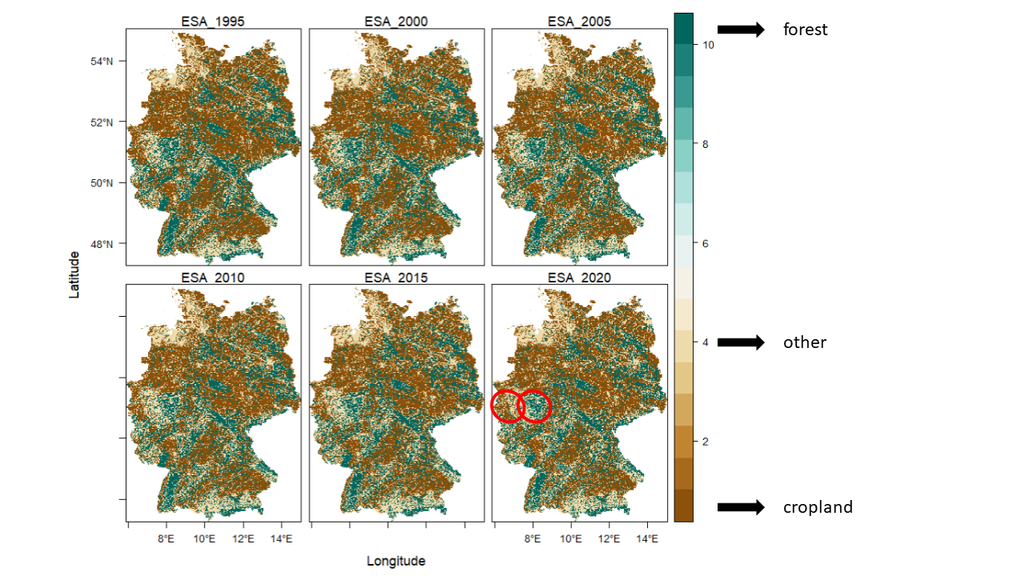

We have been observing that visually it is very difficult to see if forest and cropland changes happened in Germany between 1992-2020. In the red circles are marked two areas where maybe is possible to observe some cropland and forest loss in the **Nordrhein-Westfalen** state, but we don’t have much confidence in this statement.

We then checked the same, but numerically. We first found the number of pixels per LULC class and year, and then calculated the number of pixels that increased or decreased per LULC class compared to the based line 1992.

The second question is:

2. If we quantify the changes numerically, can we see forest and cropland changes in Germany?

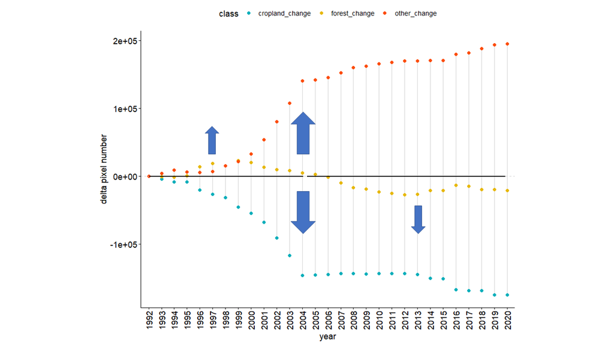

B) Numeric changes.

Afterwards, we wanted to see how these quantified changes were spatially distributed across the different states of Germany. We, thus, classified the pixels that were:

- forest in 1992 (but not anymore in 2020) as forest loss
- non-forest in 1992 (but forest in 2020) as forest gain
- cropland in 1992 (but not anymore in 2020) as cropland loss
- non-cropland in 1992 (but forest in 2020) as cropland gain

The third question is:

3. Could we visually identify which German states had high area change of cropland and forest?

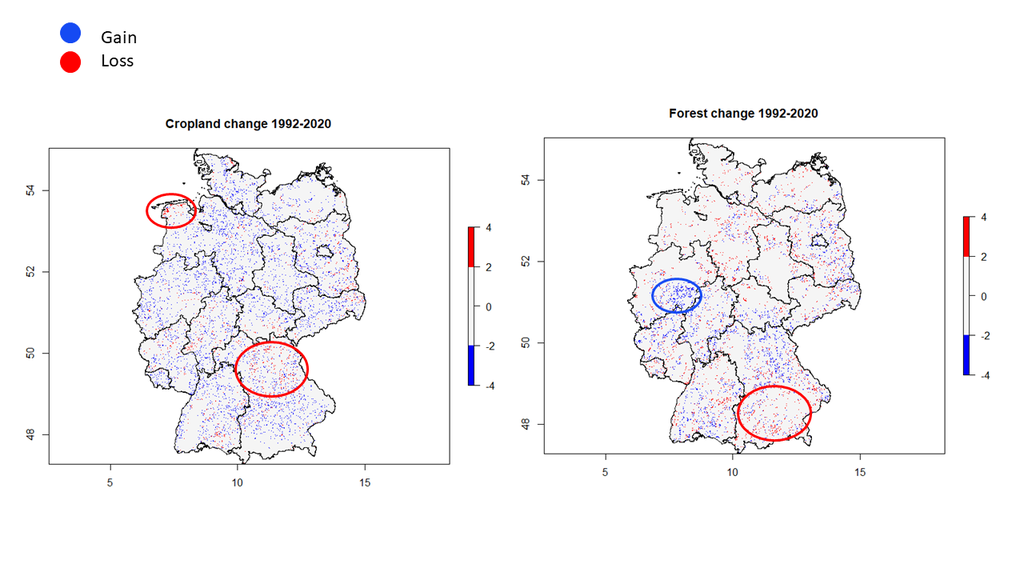

C) Spatial Visual changes.

Visually it seemed that **Niedersachsen** and **Bayern** had higher cropland loss compared to the other states. **Bayern** also had higher forest loss, while **Nordrhein-Westfalen** seemed to be the state with the highest forest gain.

But then, as before we did the same checks numerically. We calculated the area (in %) for each state that went under cropland (loss/gain) and forest (loss/gain).

The forth question is:

4. Can we now give the same answers to the question above?

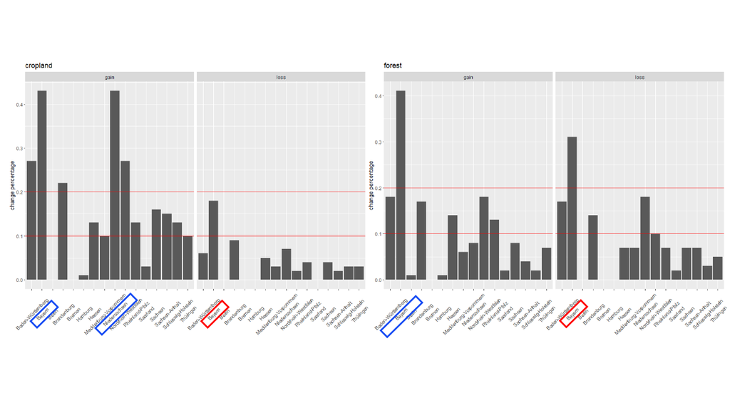

D) Spatial Numerical changes.

Numerically, the highest cropland gain (in %) was observed in **Niedersachsen** and **Bayern**, while **Bayern** had the highest cropland loss during the period 1992-2020. Although different cropland dynamics have been happening in **Bayern**, cropland gain was still higher than the loss meaning that the state has invested substantially in cropland expansion.

About forest, the highest forest loss and gain (in %) were observed in **Bayern**, but forest gain was still higher than forest loss.

In conclusion,**Bayern** seemed the German state where the highest dynamics of forest and cropland happened during the study period. The state showed a very similar % of area that went under cropland and forest expansion, although the forest loss was higher than the cropland loss.

Finally, we wanted to look at the quality of the map layers that we have been using. For that we used ground-samples collected in the field and which we consider as the truth. We then compared the classes reported on the field with the classes declared by the ESA-CCI maps to understand their quality by calculating the F1 score.

The fifth question is:

5. Did we had a good spatial distribution of ground-truth samples during the validation? And were the F1 scores good enough?

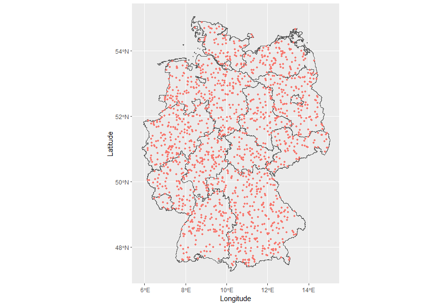

After sub-sampling 500 random samples per class, we had a very nice homogeneous spatial distribution that is very important during the validation. If you remember the **F1-forest** was **0.774**, while the **F1-cropland** was **0.768**. Normally accuracy values above 0.7 are considered good values to trust the maps.